# Parte 2 - Instalação de pacotes

Além dos recursos fornecidos no r-base, o R conta com mais de 10 mil pacotes disponíveis no CRAN e mais milhares disponíveis no Github. Os pacotes são essenciais para uma boa experiência com o R, pois podem:

- facilitar a forma de programar;
  - dplyr (%>%)
- acelerar o tempo de processamento;
  - gpuR
  - Parallel
- melhorar os recursos gráficos;
  - ggplot2
  - raster e rasterVis
  - fields
  - lattice e latticeExtra
- gerar modelos / resolver equações em uma linha de comando;
  - caret
  - h2o
  - odesolve (equações diferenciais)
- diagramar notebooks como esse;
  - RMarkdown
- integrar o R com outras linguagens;
  - RCpp
  - RFortran
  - rJava

> Vamos visitar o CRAN: https://cran.r-project.org/

## Instalando pacotes do CRAN

Os pacotes disponíveis no CRAN são os mais fáceis de instalar, o comando para isso é:

```r
install.packages(pkgs="nome do pacote",lib="diretorio")

# e para remover temos o comando equivalente:
remove.packages(pkgs = "nome do pacote",lib="diretorio")
```

Tentem instalar o pacote “devtools”.

## Instalando pacotes via Github

O pacote devtools possibilita instalar pacotes diretamente do github. no github podemos encontrar pacotes que ainda não se encontram no CRAN ou baixar versões mais recentes e/ou em desenvolvimento.

```r
library(devtools)
install_github("nome do repositorio")
```

Em ocasiões muito específicas pode ser necessário compilar manualmente o código-fonte de algum pacote. Não vamos abordar essa situação pois cada pacote tem sua particularidade. Nesse caso o mais adequado é buscar um passo-a-passo na internet.

# Análise de exploratória em dados de estações do INMET

Para começarmos a fazer algumas análises estatísticas no R, vamos utilizar dados de estações automáticas do INMET. Os dados podem ser baixados no link abaixo:

> https://drive.google.com/open?id=1LLE61RbQ1EhFpwSSZzTsAIN0kbVSZwxw

Agora vamos criar um projeto no RStudio chamado “AnaliseINMET”. Uma vez criado o projeto, vamos mover os dados baixados para um diretório chamado “dados” dentro do diretório do projeto. Dessa forma o acesso fica mais simples. Abra um novo script no projeto e salve com algum nome como “analise.R”. Escolha uma das estações diponíveis e abra o arquivo txt no **Gedit**.

**Tarefa**  
Procure a documentação da função `read.table` com a função `help("read.table")` e utilize os argumentos da para fazer a leitura da tabela considerando somente as linhas de interesse, ou seja, a partir da linha que contém os nomes das variáveis. Desejamos também manter os nomes da colunas com os nomes das variáveis.

| Estacao | Data | Hora | TempBulboSeco | TempBulboUmido | UmidadeRelativa | PressaoAtmEstacao | DirecaoVento | VelocidadeVento | Nebulosidade | X |
| --- | --- | --- | --- | --- | --- | --- | --- | --- | --- | --- |
| 83781 | 01/01/1998 | 0 | 23.5 | 21.2 | 81 | 925.1 | 9 | 2.6 | 10 | NA |
| 83781 | 01/01/1998 | 1200 | 25.3 | 21.6 | 71 | 925.2 | 5 | 1.3 | 8 | NA |
| 83781 | 01/01/1998 | 1800 | 26.3 | 22.4 | 71 | 924.3 | 18 | 2.0 | 10 | NA |
| 83781 | 02/01/1998 | 0 | 25.4 | 21.6 | 71 | 925.5 | 14 | 2.0 | 8 | NA |
| 83781 | 02/01/1998 | 1200 | 26.8 | 21.3 | 60 | 924.9 | 27 | 2.3 | 9 | NA |
| 83781 | 02/01/1998 | 1800 | 31.4 | 22.6 | 45 | 923.3 | 32 | 2.6 | 8 | NA |

Surgiu uma coluna nomeada “X” com valores ausentes. Isso aconteceu pois o arquivo do INMET possui um último " ; " depois da última coluna de dados, e o R entende que depois dele virá uma nova coluna. Vamos removê-la:

```r
df_sp$X <- NULL

## Vamos remover o número da estação que não será útil

df_sp$Estacao <- NULL
summary(df_sp)
```

```
##          Data            Hora      TempBulboSeco   TempBulboUmido
##  01/01/1998:    3   Min.   :   0   Min.   : 6.00   Min.   : 4.80
##  01/01/1999:    3   1st Qu.:   0   1st Qu.:18.20   1st Qu.:15.60
##  01/01/2000:    3   Median :1200   Median :21.20   Median :17.90
##  01/01/2001:    3   Mean   : 990   Mean   :21.36   Mean   :17.68
##  01/01/2002:    3   3rd Qu.:1800   3rd Qu.:24.40   3rd Qu.:20.20
##  01/01/2003:    3   Max.   :1800   Max.   :35.90   Max.   :26.70
##  (Other)   :21498                  NA's   :2       NA's   :105
##  UmidadeRelativa  PressaoAtmEstacao  DirecaoVento   VelocidadeVento
##  Min.   : 10.00   Min.   :913.2     Min.   : 0.00   Min.   : 0.000
##  1st Qu.: 61.00   1st Qu.:923.9     1st Qu.: 9.00   1st Qu.: 1.600
##  Median : 75.00   Median :926.2     Median :14.00   Median : 2.500
##  Mean   : 71.15   Mean   :926.4     Mean   :17.07   Mean   : 2.623
##  3rd Qu.: 84.00   3rd Qu.:928.8     3rd Qu.:27.00   3rd Qu.: 3.300
##  Max.   :100.00   Max.   :939.3     Max.   :36.00   Max.   :12.000
##  NA's   :1        NA's   :3                         NA's   :9
##   Nebulosidade
##  Min.   : 0.000
##  1st Qu.: 6.000
##  Median : 9.000
##  Mean   : 7.342
##  3rd Qu.:10.000
##  Max.   :10.000
##  NA's   :6
```

Vamos fazer a média diária das variáveis. Para isso, vamos usar precisar manipular a coluna de datas. É conveniente neste momento usar o comando `sapply`. Esse comando faz parte de uma família de comandos cujo o objetivo é aplicar uma função a um data.frame, lista ou vetor.

> lapply e sapply

Aplicam uma função a uma lista ou vetor. O `lapply` retorna uma lista e o `sapply` retorna um vetor.

> apply

Aplica uma função nas colunas ou linhas de um data.frame

> mcapply

Vale ainda mencionar o `mcapply` da biblioteca parallel. Esse comando possui a mesma funcionalidade do apply e possibilita controlar quantos núcleos do processador serão utilizados

```r
# vamos criar colunas separadas para dia, mês e ano usando o strsplit e o sapply

# primeiro testem o comando strsplit e vejam a saída, removam o # da linha abaixo
# strsplit(x = as.character(df_sp$Data),split = "/")

df_sp$mes <- sapply(strsplit(x = as.character(df_sp$Data),split = "/"),FUN = '[',2)
df_sp$ano <- sapply(strsplit(x = as.character(df_sp$Data),split = "/"),FUN = '[',3)

# podemos escrever  o mesmo comando usando a sintaxe com %>%, muitos usuários
# argumentam que essa sintaxe possui mais clareza

library(dplyr)
df_sp$mes <- df_sp$Data %>% as.character() %>% strsplit(split="/") %>% sapply(FUN='[',2)
df_sp$ano <- df_sp$Data %>% as.character() %>% strsplit(split="/") %>% sapply(FUN='[',3)
```

Agora temos a data separada em colunas, podemos fazer médias diárias, mensais e anuais. Para isso podemos usar o comando `aggregate`. A função aggregate aceita objetos do tipo **fórmula** como padrão de agregamento. Veja `help(stats::aggregate)`.

```r
temp_mensal <- aggregate(TempBulboSeco ~ mes + ano, data = df_sp, mean)
kable(temp_mensal) #digite somente temp_mensal
```

| mes | ano | TempBulboSeco |
| --- | --- | --- |
| 01 | 1998 | 24.73333 |
| 02 | 1998 | 24.97619 |
| 03 | 1998 | 24.30968 |
| 04 | 1998 | 22.25000 |
| 05 | 1998 | 18.66774 |
| 06 | 1998 | 17.02111 |
| 07 | 1998 | 17.68925 |
| 08 | 1998 | 20.25376 |
| 09 | 1998 | 19.52778 |
| 10 | 1998 | 19.56882 |
| 11 | 1998 | 21.02000 |
| 12 | 1998 | 23.63656 |
| 01 | 1999 | 23.91613 |
| 02 | 1999 | 24.26667 |
| 03 | 1999 | 23.83118 |
| 04 | 1999 | 21.13333 |
| 05 | 1999 | 18.15161 |
| 06 | 1999 | 17.07333 |
| 07 | 1999 | 17.86129 |
| 08 | 1999 | 18.16989 |
| 09 | 1999 | 19.81667 |
| 10 | 1999 | 18.81183 |
| 11 | 1999 | 20.15333 |
| 12 | 1999 | 23.30538 |
| 01 | 2000 | 23.47957 |
| 02 | 2000 | 23.16897 |
| 03 | 2000 | 22.50753 |
| 04 | 2000 | 21.81000 |
| 05 | 2000 | 19.06989 |
| 06 | 2000 | 19.28222 |

[output cut: 210 more lines]

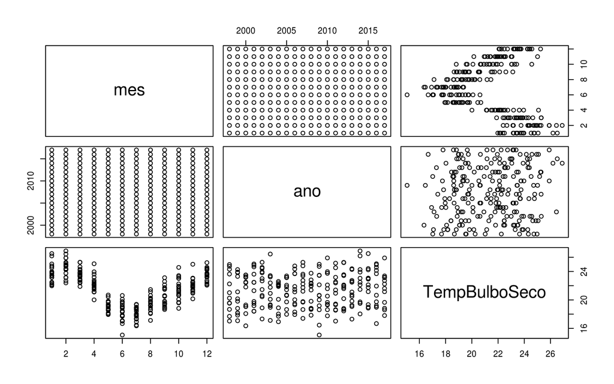

```r
plot(temp_mensal)
```

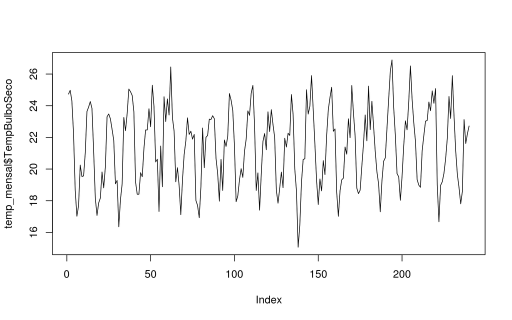

```r
plot(temp_mensal$TempBulboSeco,type="l")
```

Agora vamos colocar as datas no eixo X e arrumar os nomes dos eixos.

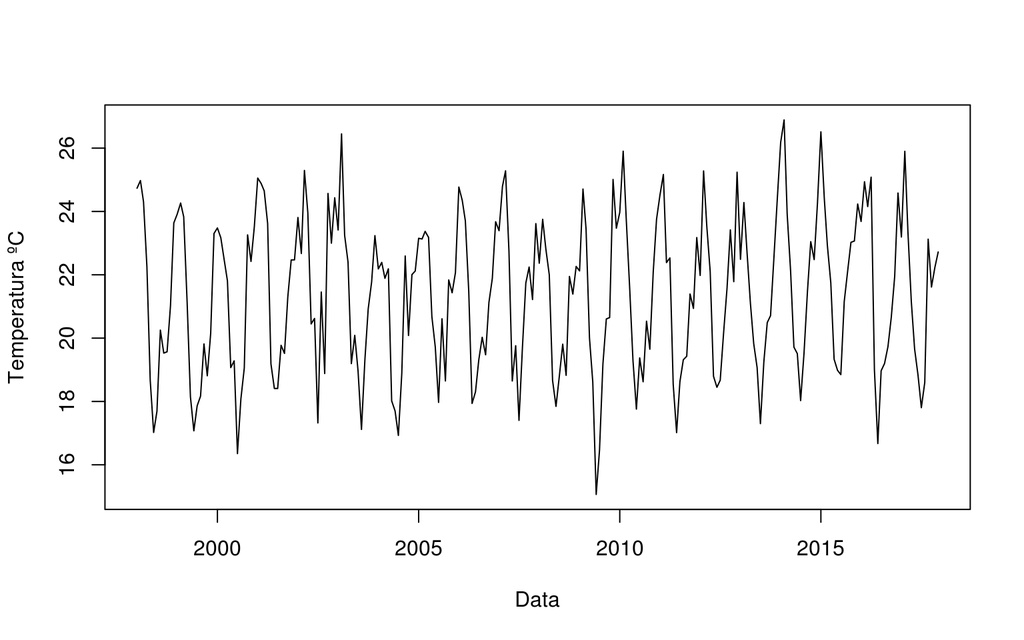

```r
datas <- seq(as.Date("1998-01-01"),as.Date("2017-12-31"),by="month")
plot(x=datas, y=temp_mensal$TempBulboSeco, xlab = "Data", ylab = "Temperatura ºC",type = "l")
```

*Exercício*

Faça o mesmo processo para obter um vetor com as médias diárias e um vetor com a temperatura média de cada mês (12 valores). Faça os plots correspondentes com as datas no eixo x.

## Transformada de Fourier

Os plots preliminares revelam que existem oscilações periódicas nas variáveis observadas. É natural tentar entender quais são as frequências dominantes nessas séries temporais.

Vamos explorar a função nativa do r `spec.pgram`:

```r
help("spec.pgram")
```

Notem que a função `spec.pgram` espera como entrada uma variável do tipo “time series”. Vamos transformar nosso vetor de observações em uma variável `ts`.

```r
ts_temp_sp <- ts(temp_mensal$TempBulboSeco,start = 1998, end = 2018, frequency = 12)
class(ts_temp_sp)
```

```
## [1] "ts"
```

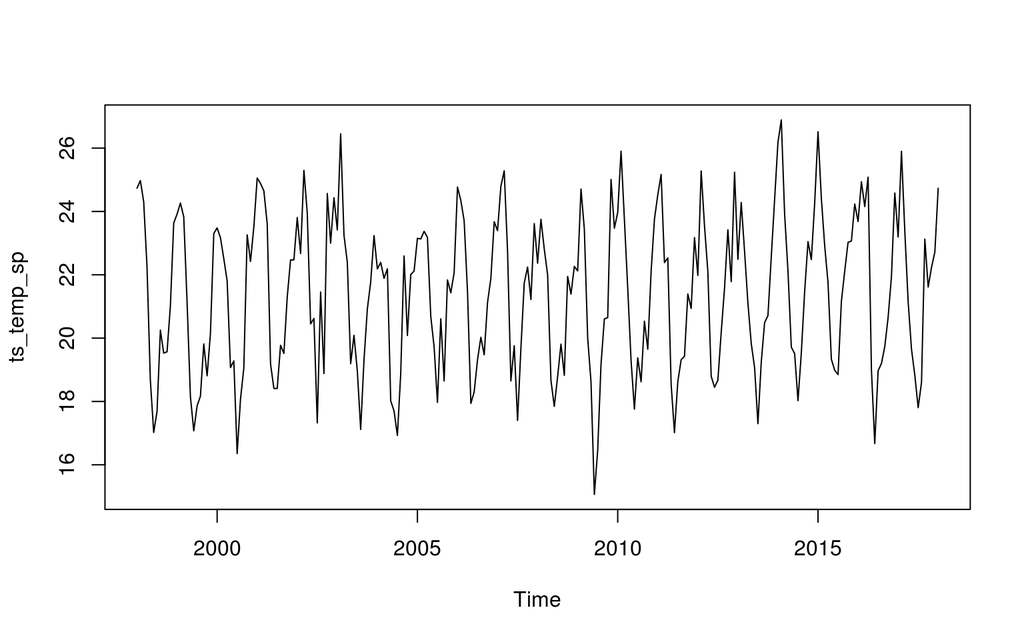

```r
plot(ts_temp_sp) # Note que ao plotar uma variável ts o eixo x já recebe corretamente as datas
```

**Exercício** É uma boa prática normalizar a série temporal antes de fazer a análise de Fourier, i.e. ${x}=0 $ e $x^2 \le1$. Normalize o vetor `ts_temp_sp`.

Depois de normalizado, vamos fazer a transformada no vetor.

```r
fft_temp <- spec.pgram(ts_temp_sp, plot=FALSE)

# Vamos examinar o objeto fft_temp
fft_temp
```

```
## $freq
##   [1] 0.04938272 0.09876543 0.14814815 0.19753086 0.24691358 0.29629630
##   [7] 0.34567901 0.39506173 0.44444444 0.49382716 0.54320988 0.59259259
##  [13] 0.64197531 0.69135802 0.74074074 0.79012346 0.83950617 0.88888889
##  [19] 0.93827160 0.98765432 1.03703704 1.08641975 1.13580247 1.18518519
##  [25] 1.23456790 1.28395062 1.33333333 1.38271605 1.43209877 1.48148148
##  [31] 1.53086420 1.58024691 1.62962963 1.67901235 1.72839506 1.77777778
##  [37] 1.82716049 1.87654321 1.92592593 1.97530864 2.02469136 2.07407407
##  [43] 2.12345679 2.17283951 2.22222222 2.27160494 2.32098765 2.37037037
##  [49] 2.41975309 2.46913580 2.51851852 2.56790123 2.61728395 2.66666667
##  [55] 2.71604938 2.76543210 2.81481481 2.86419753 2.91358025 2.96296296
##  [61] 3.01234568 3.06172840 3.11111111 3.16049383 3.20987654 3.25925926
##  [67] 3.30864198 3.35802469 3.40740741 3.45679012 3.50617284 3.55555556
##  [73] 3.60493827 3.65432099 3.70370370 3.75308642 3.80246914 3.85185185
##  [79] 3.90123457 3.95061728 4.00000000 4.04938272 4.09876543 4.14814815
##  [85] 4.19753086 4.24691358 4.29629630 4.34567901 4.39506173 4.44444444
##  [91] 4.49382716 4.54320988 4.59259259 4.64197531 4.69135802 4.74074074
##  [97] 4.79012346 4.83950617 4.88888889 4.93827160 4.98765432 5.03703704
## [103] 5.08641975 5.13580247 5.18518519 5.23456790 5.28395062 5.33333333
## [109] 5.38271605 5.43209877 5.48148148 5.53086420 5.58024691 5.62962963
## [115] 5.67901235 5.72839506 5.77777778 5.82716049 5.87654321 5.92592593
## [121] 5.97530864
##
## $spec
##   [1] 2.167660e-04 5.284868e-04 5.294966e-04 3.123033e-04 7.694548e-04
##   [6] 1.934687e-05 5.432961e-05 4.778139e-04 5.153687e-04 9.844869e-05
##  [11] 3.983131e-04 1.931257e-04 1.193345e-04 5.494514e-04 1.916452e-06
##  [16] 6.215032e-04 4.515726e-05 1.360900e-04 1.731101e-03 4.389781e-02
##  [21] 1.097270e-02 2.282076e-03 1.228539e-03 1.392221e-04 1.418949e-05
##  [26] 2.860376e-04 8.021808e-05 3.343588e-04 1.421348e-04 2.992254e-05
##  [31] 2.902552e-05 4.330257e-04 2.773565e-04 3.812613e-05 2.501519e-04
##  [36] 8.298755e-05 4.744197e-05 3.555839e-04 1.772347e-04 1.249277e-03
##  [41] 2.359509e-03 2.456737e-05 1.185963e-05 4.939959e-05 2.262613e-07
##  [46] 3.365734e-04 1.762862e-05 2.216462e-05 7.593578e-06 1.514679e-04
##  [51] 1.304797e-04 2.518254e-04 1.799971e-04 3.006285e-04 2.807840e-05
##  [56] 1.172023e-04 1.393897e-05 8.119096e-05 2.675069e-05 1.140886e-04
##  [61] 1.037663e-04 6.816766e-05 1.961816e-04 2.659462e-05 2.815744e-04
##  [66] 9.910003e-05 1.115015e-04 1.226916e-04 8.075622e-05 2.074510e-05
##  [71] 5.304351e-05 3.137467e-05 2.266553e-04 6.697997e-05 2.604396e-04
##  [76] 8.729792e-05 5.312326e-05 1.691571e-04 3.170516e-05 6.404040e-05
```

[output cut: 39 more lines]

```
##
## $taper
## [1] 0.1
##
## $pad
## [1] 0
##
## $detrend
## [1] TRUE
##
## $demean
## [1] FALSE
##
## attr(,"class")
## [1] "spec"
```

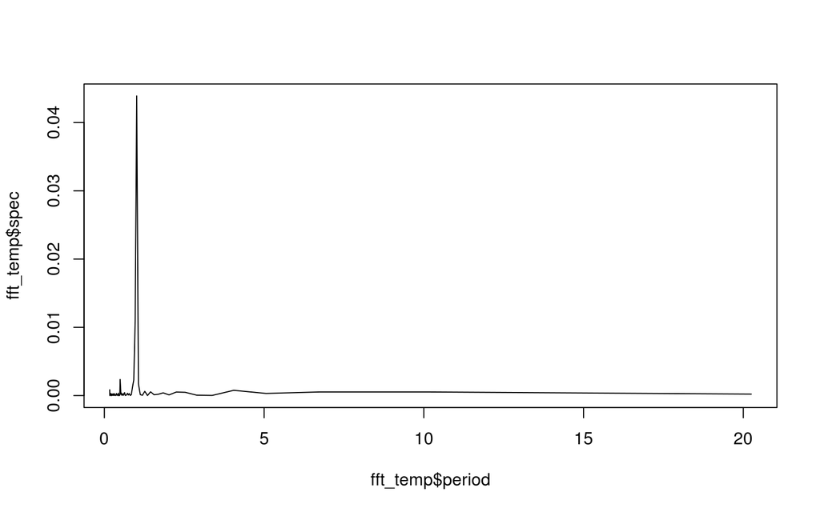

```r
# O objeto é uma lista onde "spec" contém a potência de cada frequência "freq"
# Para obter o período basta inverter a frequência

fft_temp$period <- 1/fft_temp$freq

plot(x = fft_temp$period, y = fft_temp$spec,type = "l")
```

```r
# Por último, vamos criar um data.frame com as informações relevantes da transformada

df_fft_temp <- data.frame(period = fft_temp$period, spec = fft_temp$spec)
```

Naturalmente, o plot mostra que o período anual é o mais importante para a temperatura. No entanto, vamos gerar uma tabela com os períodos mais importantes em ordem decrescente.

> Tarefa: Vamos procurar no Google como ordenar uma tabela no R usando os valores de uma coluna. Queremos ordenar nossa tabela fft_temp com a coluna spec

> O que os períodos mais energéticos podem nos dizer?

| period | spec |
| --- | --- |
| 1.0125000 | 0.0438978 |
| 0.9642857 | 0.0109727 |
| 0.4939024 | 0.0023595 |
| 0.9204545 | 0.0022821 |
| 1.0657895 | 0.0017311 |
| 0.5062500 | 0.0012493 |
| 0.8804348 | 0.0012285 |
| 0.1673554 | 0.0008425 |
| 4.0500000 | 0.0007695 |
| 1.2656250 | 0.0006215 |

## Matriz de correlação

A matriz de correlação é uma ferramenta útil na análise exploratória de uma base de dados e quantifica a relação linear entre todas as variáveis da tabela. No R, o comando é o seguinte:

```r
cor(x, method = c("pearson","kendall","spearman"))
# o método default é o pearson, mas podemos escolher entre os três
```

A correlação de Pearson é dada pela seguinte equação:
$$r_{xy} = \frac{Cov(X,Y)}{S_xS_y} = \frac{\sum(x_i-\bar{x})(y_i-\bar{y})}{\sqrt{\sum(x_i-\bar{x})^2(y_i-\bar{y})^2}}$$
Onde $S$ é o desvio padrão.

Agora vamos analisar nosso data.frame `df_sp`. Devemos inicialmente remover as colunas com valores não numéricos.

```r
names(df_sp)
```

```
##  [1] "Data"              "Hora"              "TempBulboSeco"
##  [4] "TempBulboUmido"    "UmidadeRelativa"   "PressaoAtmEstacao"
##  [7] "DirecaoVento"      "VelocidadeVento"   "Nebulosidade"
## [10] "mes"               "ano"
```

```r
df_sp_num <- df_sp[,c(-1,-2,-10,-11)]
cor(df_sp_num)
```

```
##                   TempBulboSeco TempBulboUmido UmidadeRelativa
## TempBulboSeco                 1             NA              NA
## TempBulboUmido               NA              1              NA
## UmidadeRelativa              NA             NA               1
## PressaoAtmEstacao            NA             NA              NA
## DirecaoVento                 NA             NA              NA
## VelocidadeVento              NA             NA              NA
## Nebulosidade                 NA             NA              NA
##                   PressaoAtmEstacao DirecaoVento VelocidadeVento
## TempBulboSeco                    NA           NA              NA
## TempBulboUmido                   NA           NA              NA
## UmidadeRelativa                  NA           NA              NA
## PressaoAtmEstacao                 1           NA              NA
## DirecaoVento                     NA            1              NA
## VelocidadeVento                  NA           NA               1
## Nebulosidade                     NA           NA              NA
##                   Nebulosidade
## TempBulboSeco               NA
## TempBulboUmido              NA
## UmidadeRelativa             NA
## PressaoAtmEstacao           NA
## DirecaoVento                NA
## VelocidadeVento             NA
## Nebulosidade                 1
```

Todas as correlações resultaram como `NA` pois existem valores faltantes na tabela. Uma possível solução para isso é usar a função `na.omit`.

```r
m_cor <- df_sp_num %>% na.omit() %>% cor()
# m_cor <- cor(na.omit(df_sp_num))

kable(m_cor,digits = 2)
```

|  | TempBulboSeco | TempBulboUmido | UmidadeRelativa | PressaoAtmEstacao | DirecaoVento | VelocidadeVento | Nebulosidade |
| --- | --- | --- | --- | --- | --- | --- | --- |
| TempBulboSeco | 1.00 | 0.82 | -0.66 | -0.58 | 0.30 | 0.01 | -0.16 |
| TempBulboUmido | 0.82 | 1.00 | -0.13 | -0.64 | 0.20 | -0.05 | 0.08 |
| UmidadeRelativa | -0.66 | -0.13 | 1.00 | 0.18 | -0.26 | -0.08 | 0.42 |
| PressaoAtmEstacao | -0.58 | -0.64 | 0.18 | 1.00 | -0.31 | -0.05 | -0.09 |
| DirecaoVento | 0.30 | 0.20 | -0.26 | -0.31 | 1.00 | 0.21 | 0.00 |
| VelocidadeVento | 0.01 | -0.05 | -0.08 | -0.05 | 0.21 | 1.00 | 0.20 |
| Nebulosidade | -0.16 | 0.08 | 0.42 | -0.09 | 0.00 | 0.20 | 1.00 |

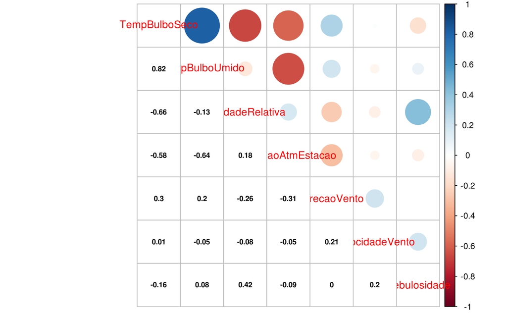

```r
library(corrplot)
corrplot.mixed(m_cor, lower.col = "black", number.cex = .7)
```

**Para discutir**

Discutam com o colega de mesa as seguintes questões.

```
- Por que a temperatura e a direção do vento se correlacionam positivamente?

- Por que a temperatura e a nebulosidade se correlacionam negativamente?

- Por que a temperatura e a umidade relativa se correlacionam negativamente?
```

## Regressão linear

Modelagem estatística talvez seja o ponto mais forte do R. O pacote nativo `stats` conta com uma ampla coleção de técnicas e modelos. Entretanto, existem pacotes que expandem as capacidades do R e possibilitam a utilização de técnicas modernas e altamente eficientes do ponto de vista computacional. Quem deseja trabalhar com modelos mais complexos vale a pena investigar pacotes como keras, caret, h2o e mxnet.

Vamos começar trabalhando com os comandos nativos.

```r
names(df_sp)
```

```
##  [1] "Data"              "Hora"              "TempBulboSeco"
##  [4] "TempBulboUmido"    "UmidadeRelativa"   "PressaoAtmEstacao"
##  [7] "DirecaoVento"      "VelocidadeVento"   "Nebulosidade"
## [10] "mes"               "ano"
```

```r
df_lm <- df_sp[ , c(3,4,5,6,7,8,9)]

### Agora vamos normalizar nosso dataframe usando apply

normalize <- function (x) {
  x/max(x,na.rm = TRUE)
}
```

**Exercício** Usando o comando `apply`, aplique a função `normalize` que acabamos de criar nas colunas do dataframe `df_lm`. Verifique se a saída desse comando será da classe `data.frame`, caso não seja, transforme nessa classe.

Finalmente, vamos aplicar o modelo linear:

```r
modLinear <- lm(TempBulboSeco ~ PressaoAtmEstacao, data = df_lm)
```

> Agora vamos interpretar a regressão

```r
summary(modLinear)
```

```
##
## Call:
## lm(formula = TempBulboSeco ~ PressaoAtmEstacao, data = df_lm)
##
## Residuals:
##      Min       1Q   Median       3Q      Max
## -0.41341 -0.07107 -0.00676  0.06623  0.39164
##
## Coefficients:
##                   Estimate Std. Error t value Pr(>|t|)
## (Intercept)        19.3683     0.1782   108.7   <2e-16 ***
## PressaoAtmEstacao -19.0355     0.1806  -105.4   <2e-16 ***
## ---
## Signif. codes:  0 '***' 0.001 '**' 0.01 '*' 0.05 '.' 0.1 ' ' 1
##
## Residual standard error: 0.1027 on 21509 degrees of freedom
##   (5 observations deleted due to missingness)
## Multiple R-squared:  0.3405, Adjusted R-squared:  0.3404
## F-statistic: 1.11e+04 on 1 and 21509 DF,  p-value: < 2.2e-16
```

Volte na tabela de correlação e compare o coeficiente de pearson com o R² da regressão.

É possível plotar a reta da regressão linear:

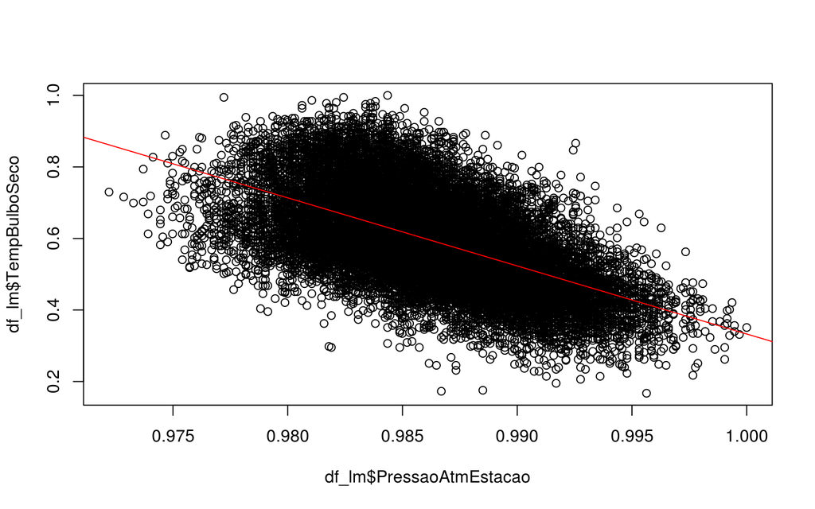

```r
plot(x = df_lm$PressaoAtmEstacao, y = df_lm$TempBulboSeco)
abline(a = modLinear$coefficients[1], b = modLinear$coefficients[2], col = "red")
```

**Atividade**

Aplique a regressão linear múltipla considerando todas as variáveis do `df_lm` e interprete a saída da função `summary`. Dica: é necessário adaptar a fórmula da função `lm()`. Se não encontrar ajuda na documentação da função, busque no Google.

Se quisermos prever uma variável categórica (não-contínua) a regressão linear não é o modelo mais adequado. Existem outros modelos mais adequados como a regressão logística

## Regressão logística

$$f(y)=\frac{1}{1+e^{-y}}$$

A regressão logística consiste em aplicar a função logística em um modelo linear $y=ax+b$.

$$f(ax+b)=\frac{1}{1+e^{-ax-b}}$$
As constantes a e b podem ser encontradas invertendo a função logística e aplicando o método dos mínimos quadrados.

A saída da função logística pode ser interpretada como a probabilidade de um evento ocorrer. Embora a função seja não-linear, o classificador é linear pois é definido um threshold (limiar) de decisão, em geral esse limiar é 0.5. Veja o gráfico da função logística:

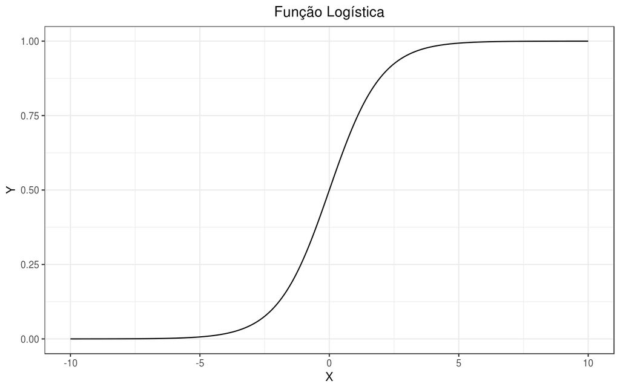

A regressão logística pode ser computada pelo comando glm do pacote stats (nativo). Essa função é uma extensão mais flexível do lm.

```r
df_lm$Nebulosidade <- as.factor(df_lm$Nebulosidade)
logisticReg <- glm(Nebulosidade ~  . , data = df_lm, family = binomial(link="logit"))
```

## Análise de componentes principais (PCA)

A PCA é uma transformação linear ortogonal (W) que projeta os dados (X) em uma base onde as variáveis não possuem correlação linear (Z). As colunas de W são os autovetores da matriz de covariância de X.
$$Z_{n,m} = X_{n,m}W{m,m}$$
A PCA é útil para (1) reduzir a dimensão da base de dados (2) encontrar os padrões lineares dominantes na série.

Vamos então aplicar a PCA com a função `prcomp` no nosso dataframe `df_sp`. Como o ciclo diurno vai causar um sinal muito forte, vamos pegar somente o horário das 18Z.

```r
# Vamos informar para o R que a coluna de "Data" do df_sp realmente se trata de variáveis tipo date
df_sp$Data<-as.Date(df_sp$Data,format="%d/%m/%Y")


df_pca <- df_sp[which(df_sp$Hora=="1800"),c(1,3,4,5,6,7,8,9)]

# Pegar somente as linhas sem observações faltantes (NA)

mask <- complete.cases(df_pca)
df_pca <- df_pca[mask,]

# Vamos transformar as colunas do df_pca em variáveis numéricas

df_pca_numeric <- apply(df_pca[,-1],2,as.numeric)

pca <- prcomp(df_pca_numeric, center = TRUE, scale = TRUE)
summary(pca)
```

```
## Importance of components:
##                          PC1    PC2    PC3    PC4    PC5     PC6     PC7
## Standard deviation     1.616 1.3453 1.0429 0.8424 0.6588 0.58169 0.09517
## Proportion of Variance 0.373 0.2586 0.1554 0.1014 0.0620 0.04834 0.00129
## Cumulative Proportion  0.373 0.6316 0.7870 0.8884 0.9504 0.99871 1.00000
```

Observe que com 5 componentes já é possível explicar mais de 90% da variância da série.

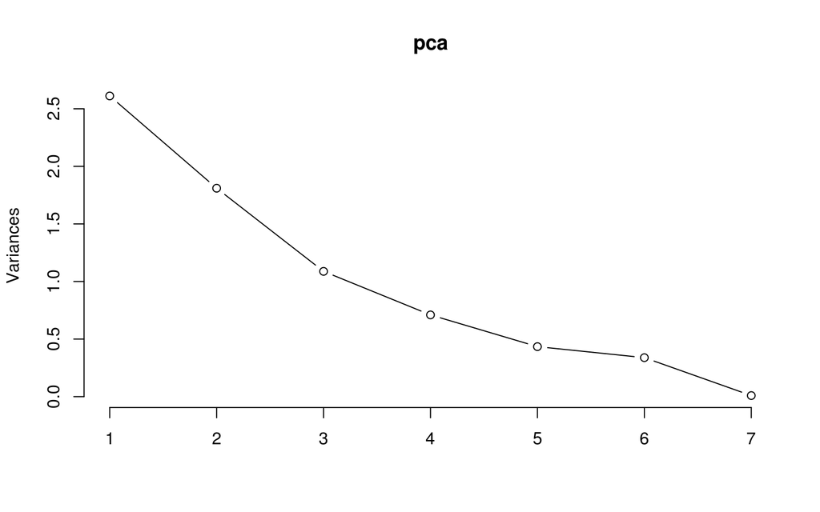

```r
plot(pca, type="l")
```

Para prever as componentes principais de novas observações ou das observações que usamos para calcular a PCA podemos utilizar a função predict:

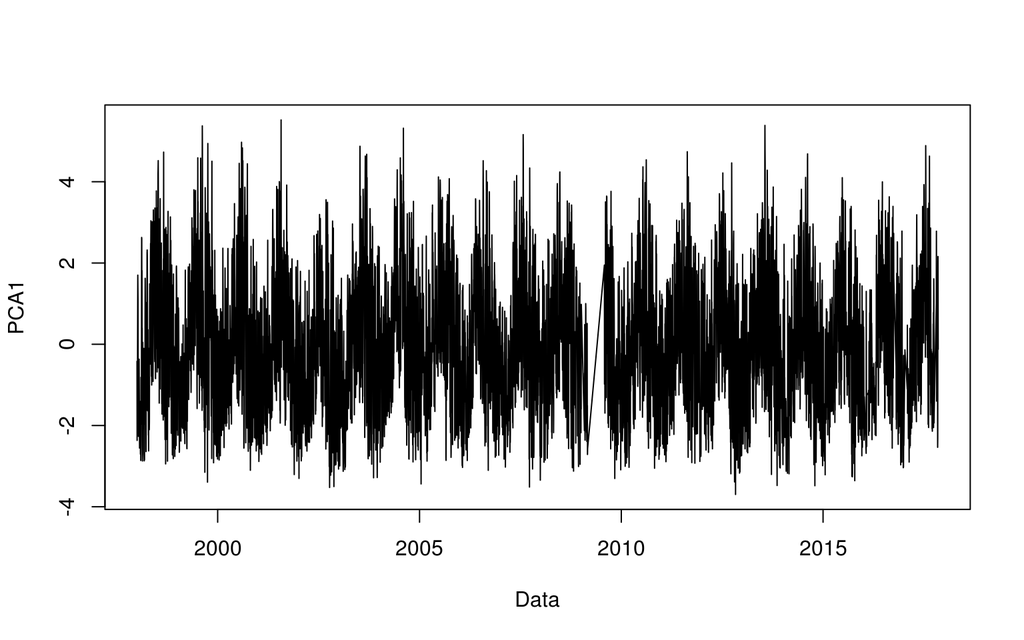

```r
PCA <- predict(pca, df_pca)
# precisamos remover os dias ocorreram dados ausentes do vetor de datas
plot(PCA[,1], x = df_pca$Data, type = "l", xlab = "Data", ylab = "PCA1")
```

O ciclo anual aparece de maneira evidente na primeira componente principal.

Um biplot é útil para extrair informações das componentes principais. Para isso vamos usar o pacote gráfico `ggplot2` e o pacote auxiliar `ggbiplot` que deve ser instalado do github:

```r
library(devtools)
install_github("vqv/ggbiplot")
```

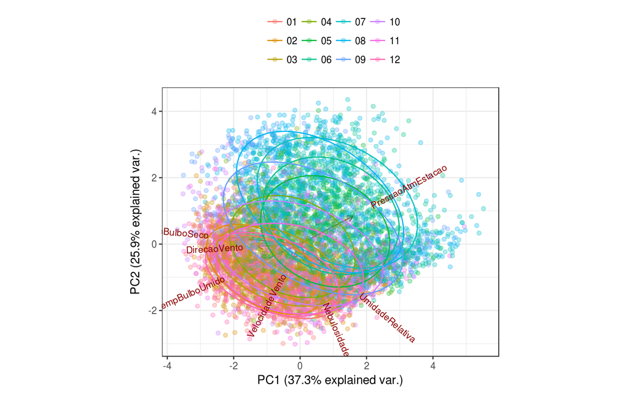

```r
library(ggplot2)
library(ggbiplot)
mes <- format(df_pca$Data,"%m")

g <- ggbiplot(pca, obs.scale = 1, var.scale = 3,var.axes = TRUE,
              groups = mes,alpha = 0.3,
              ellipse = TRUE)
g <- g + scale_color_discrete(name = '')
g <- g + theme(legend.direction = 'horizontal',
               legend.position = 'top')
print(g)
```

**Salvando o output gráfico**

Para salvar os gráficos do R, existem as funções png(), gif(), jpeg(), tiff, pdf(), entre outras. Procure na documentação do R sobre a função png() e exporte o gráfico que fizemos acima.

# Aprimorando os gráficos com o ggplot2

O `ggplot2` é um pacote tão grande do R que quase poderia ser considerado outra linguagem. Vamos seguir os tutoriais abaixo.

http://r-statistics.co/Complete-Ggplot2-Tutorial-Part1-With-R-Code.html

http://r-statistics.co/Top50-Ggplot2-Visualizations-MasterList-R-Code.html

# Exercício

1 - Reproduza os plots da parte 2 usando o ggplot2 e pense em um novo plot baseado nas ideias do top50. Salve a saída dos plots que fizer e envie para `gabrielmpp2@gmail.com`.

3 - Instale o pacote openair e use a função windrose para fazer um plot tipo rosa dos ventos somente com os dados da estação meteorológica escolhida nos meses de Dezembro, Janeiro e Fevereiro

Gabriel Perez - gabrielmpp2@gmail.com

2018-02-01